# Used Car Prediction

2023-04-15

**Load the required libraries and dataset**

```r
# Load the libraries
library(ggplot2)
library(tidyverse)
library(corrplot)
library(caret)
library(randomForest)
#library(rsq)
library(e1071)
library(stats)
library(Metrics)
library(doParallel)
library(SuperLearner)
set.seed(123)
```

# Data Acquisition

Load the dataset

```r
# Load the dataset
URL = "https://raw.githubusercontent.com/insaid2018/Term-1/master/Data/Projects/car_sales.csv"
df <- read.csv(URL)
head(df)
```

```
##             car price      body mileage engV engType registration year   model
## 1          Ford 15500 crossover      68  2.5     Gas          yes 2010    Kuga
## 2 Mercedes-Benz 20500     sedan     173  1.8     Gas          yes 2011 E-Class
## 3 Mercedes-Benz 35000     other     135  5.5  Petrol          yes 2008  CL 550
## 4 Mercedes-Benz 17800       van     162  1.8  Diesel          yes 2012   B 180
## 5 Mercedes-Benz 33000     vagon      91   NA   Other          yes 2013 E-Class
## 6        Nissan 16600 crossover      83  2.0  Petrol          yes 2013 X-Trail
##   drive
## 1  full
## 2  rear
## 3  rear
## 4 front
## 5
## 6  full
```

# Data Exploration

The car prices data will visualized in plots and graphs. The graphs will help to compare different groups, detect outliers as well as finding distribution of continuous values.

## Comparison

Compare different model price.

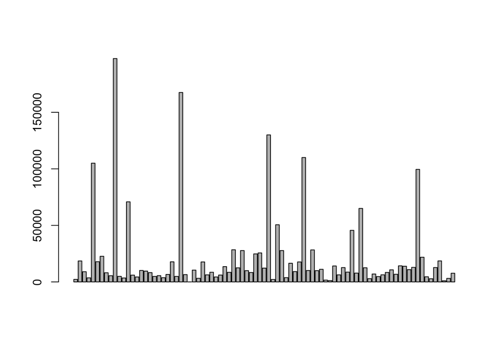

```r
#Groupby make/model
df_makes = df %>% group_by(car)  %>%
  summarise(average_price = mean(price),
            .groups = 'drop')

#Plot the bar chart
barplot(height=df_makes$average_price)
```

```r
# memory management
rm(df_makes)
```

The average price for each model was compared, there were models that were more expensive than others

## Outlier detection

Does the dataset contain outliers? Lets inspect the outliers for continuous variables. The detected outliers will be removed from the dataset, but before we remove outliers lets inspect the null values available in the dataset

```r
sum(is.na(df))
```

```
## [1] 434
```

There are 434 null values in the dataset but let’s inspect the outliers and work on the null data points

**Outliers in price**

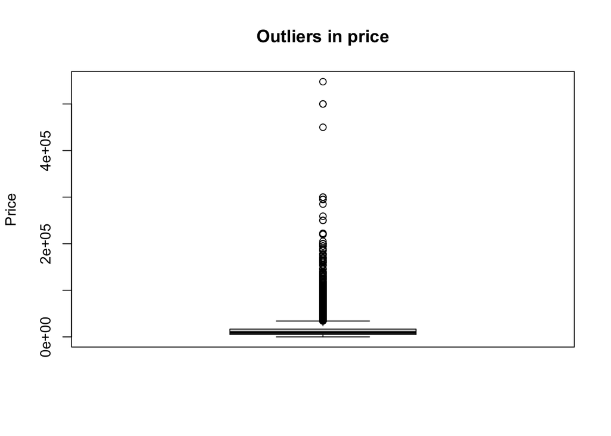

```r
boxplot(df$price,
        main = "Outliers in price",
        ylab = "Price")
```

```r
df <- subset(df, price < 24000)
dim(df)
```

```
## [1] 8156   10
```

**Outliers in mileage**

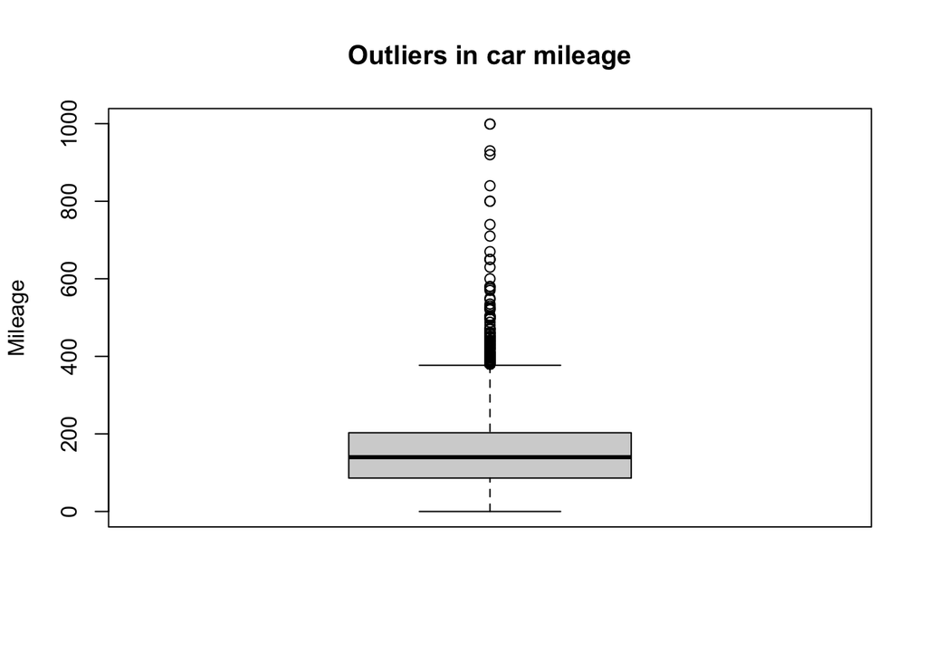

```r
boxplot(df$mileage,
        main = "Outliers in car mileage",
        ylab = "Mileage")
```

Values more than 350 in car mileage are considered as outliers. The car with more than 350 miles of mileage will be removed from the dataset

```r
df <- subset(df, mileage < 350)
dim(df)
```

```
## [1] 7871   10
```

More than 200 records were removed when removing outliers in car mileage

**Outliers in engV**

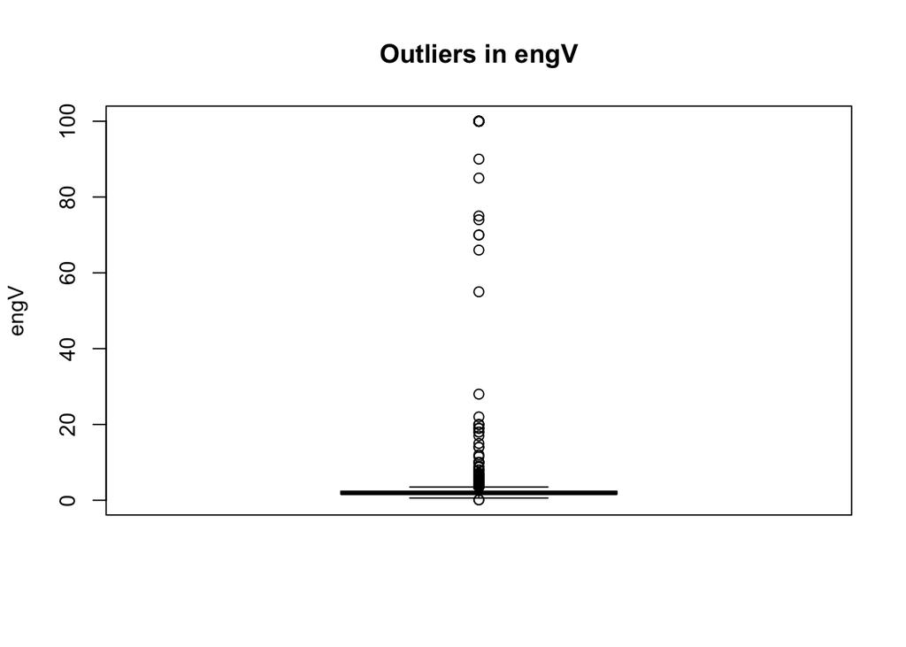

```r
boxplot(df$engV,
        main = "Outliers in engV",
        ylab = "engV")
```

Values above 3.3 and below 0.3 in engine capacity(engV) were considered as outliers.

```r
df <- subset(df, engV < 3.3 & engV > 0.3)
dim(df)
```

```
## [1] 6926   10
```

After dropping out all outliers more than 2000 records were that were outliers were removed.

## Distribution

Distribution of Mileage

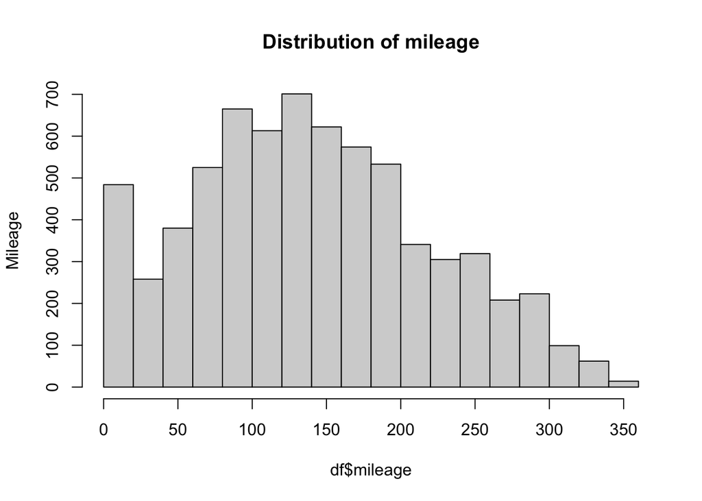

```r
hist(df$mileage,
     main = "Distribution of mileage",
     ylab = "Mileage")
```

# Data Cleaning and Shaping

Data Cleaning is very effective in any data science process, it helps to identify and fix messy data. It ensures the data being analyzed (car sales data for this case) is ready and accurate for further analysis. Poor data quality can lead to biased results that may lead to poor business decisions. It is therefore important to clean the data.

**Inspect the data shape**

```r
dim(df)
```

```
## [1] 6926   10
```

**Identification of Missing Values after imputation**

```r
df <- na.omit(df)
sum(is.na(df))
```

```
## [1] 0
```

There more than 0 null points in the dataset. Any record with null value was be removed during outlier detection therefore the dataset has no null values but there may be records that are duplicated.

```r
sum(duplicated(df))
```

```
## [1] 46
```

There were 46 duplicated records. The duplicated records will be dropped only the first one.

```r
# Use duplicated to find duplicated rows
duplicates <- duplicated(df)

# Subset the data frame to remove duplicated rows
df <- df[!duplicates, ]
rm(duplicates) #memory management

# Confirm the operation
sum(duplicated(df))
```

```
## [1] 0
```

# Feature engineering

Lets find them. The year column can be converted to year of service whereby its value will be subtracted from the current year, 2023.

```r
#Years of service
df$yearsOfService <- 2023 - df$year

# Drop the year column
df <- subset(df, select = c(-year))
head(df) #confirm the operation
```

```
##             car price      body mileage engV engType registration   model drive
## 1          Ford 15500 crossover      68  2.5     Gas          yes    Kuga  full
## 2 Mercedes-Benz 20500     sedan     173  1.8     Gas          yes E-Class  rear
## 4 Mercedes-Benz 17800       van     162  1.8  Diesel          yes   B 180 front
## 6        Nissan 16600 crossover      83  2.0  Petrol          yes X-Trail  full
## 7         Honda  6500     sedan     199  2.0  Petrol          yes  Accord front
## 8       Renault 10500     vagon     185  1.5  Diesel          yes  Megane front
##   yearsOfService
## 1             13
## 2             12
## 4             11
## 6             10
## 7             20
## 8             12
```

```r
df$mileage <- scale(df$mileage)
df$engV <- scale(df$engV)
df$yearsOfService <- scale(df$yearsOfService)
head(df)
```

```
##             car price      body    mileage       engV engType registration
## 1          Ford 15500 crossover -0.9308027  1.2281503     Gas          yes
## 2 Mercedes-Benz 20500     sedan  0.3755794 -0.1796762     Gas          yes
## 4 Mercedes-Benz 17800       van  0.2387204 -0.1796762  Diesel          yes
## 6        Nissan 16600 crossover -0.7441767  0.2225600  Petrol          yes
## 7         Honda  6500     sedan  0.6990645  0.2225600  Petrol          yes
## 8       Renault 10500     vagon  0.5248803 -0.7830304  Diesel          yes
##     model drive yearsOfService
## 1    Kuga  full     -0.5988491
## 2 E-Class  rear     -0.7451536
## 4   B 180 front     -0.8914582
## 6 X-Trail  full     -1.0377627
## 7  Accord front      0.4252826
## 8  Megane front     -0.7451536
```

All duplicated records were successfully dropped. Lets now calculate the summary statistics

```r
summary(df)
```

```
##      car                price           body                mileage.V1
##  Length:6880        Min.   :    0   Length:6880        Min.   :-1.7768407
##  Class :character   1st Qu.: 4387   Class :character   1st Qu.:-0.7192932
##  Mode  :character   Median : 7900   Mode  :character   Median :-0.0723230
##                     Mean   : 8656                      Mean   : 0.0000000
##                     3rd Qu.:11900                      3rd Qu.: 0.6990645
##                     Max.   :23999                      Max.   : 2.5279995
##        engV.V1          engType          registration          model
##  Min.   :-2.5930931   Length:6880        Length:6880        Length:6880
##  1st Qu.:-0.7830304   Class :character   Class :character   Class :character
##  Median :-0.1796762   Mode  :character   Mode  :character   Mode  :character
##  Mean   : 0.0000000
##  3rd Qu.: 0.6247961
##  Max.   : 2.6359769
##     drive            yearsOfService.V1
##  Length:6880        Min.   :-1.476676
##  Class :character   1st Qu.:-0.745154
##  Mode  :character   Median :-0.159936
##                     Mean   : 0.000000
##                     3rd Qu.: 0.425283
##                     Max.   : 6.862682
```

**Label Encoding**

They are many non numeric features in the dataset, for instance engine type, registration and car. They should be converted to numeric features by label encoding as machines only understand numbers.

```r
#Convert non numeric columns to numeric
convert_to_numeric <- function(x){
  if (typeof(x)=="character"){
    factored <- as.factor(x) #Create categories
    numerized <- as.numeric(factored) #Convert the categories into numbers
  }
  else{
    x
  }
}
df_num <- sapply(df, convert_to_numeric)

head(df_num)
```

```
##      car price body    mileage       engV engType registration model drive
## [1,]  20 15500    1 -0.9308027  1.2281503       2            2   384     3
## [2,]  40 20500    4  0.3755794 -0.1796762       2            2   271     4
## [3,]  40 17800    6  0.2387204 -0.1796762       1            2   174     2
## [4,]  46 16600    1 -0.7441767  0.2225600       4            2   644     3
## [5,]  26  6500    4  0.6990645  0.2225600       4            2   150     2
## [6,]  50 10500    5  0.5248803 -0.7830304       1            2   419     2
##      yearsOfService
## [1,]     -0.5988491
## [2,]     -0.7451536
## [3,]     -0.8914582
## [4,]     -1.0377627
## [5,]      0.4252826
## [6,]     -0.7451536
```

All the non numeric features were converted to numeric.

Log transformation was done but it produced null values hence it was not advisable to transform the non uniformly distributed features.

Compute the correlation to find variables that are more related to the target variables. The correlation matrix is then plotted onto a heatmap.

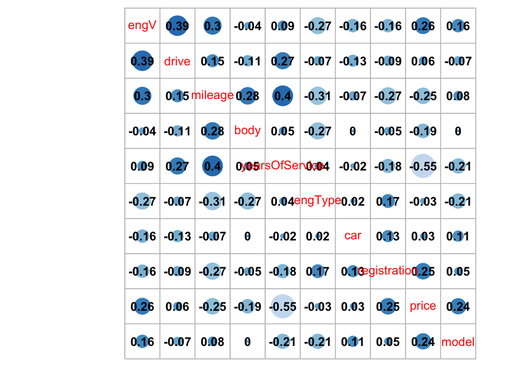

```r
cor_matrix = round(cor(df_num, method = "pearson", use = "complete.obs"), 2)

corrplot(cor_matrix, order = 'AOE', addCoef.col = 'black', tl.pos = 'd',
         cl.pos = 'n', col = COL1('Blues'))
```

yearsOfService, mileage, engine capacity(engV), model and registration had a strong correlation(above 0.23 and below 0.23) with the target variable, ‘price’. The dataframe will be filtered only to have the features and the price feature.

```r
df <- subset(df_num, select = c(yearsOfService,
                              mileage,
                              engV,
                              model,
                              registration,
                              price))

# convert to DataFrame
df <- data.frame(df)
head(df)
```

```
##   yearsOfService    mileage       engV model registration price
## 1     -0.5988491 -0.9308027  1.2281503   384            2 15500
## 2     -0.7451536  0.3755794 -0.1796762   271            2 20500
## 3     -0.8914582  0.2387204 -0.1796762   174            2 17800
## 4     -1.0377627 -0.7441767  0.2225600   644            2 16600
## 5      0.4252826  0.6990645  0.2225600   150            2  6500
## 6     -0.7451536  0.5248803 -0.7830304   419            2 10500
```

# Model Construction

## Principal Component Analysis

The PCA values will be computed for the independent features in the dataset. PCA is a dimensionality reduction technique that aims to reduce the number of independent features for easy training of the models.

```r
X <- subset(df, select = -c(price))

# Perform PCA on the select independent data
pc <- prcomp(X,
             center = TRUE,
            scale. = TRUE)
pcaX <- pc$x
head(pcaX)
```

```
##          PC1         PC2         PC3        PC4        PC5
## 1 -0.4870473  0.95676312 -0.14363151 -1.1947693  0.5281466
## 2 -0.3357204  0.01254124 -0.03025949 -0.1226091 -0.8888448
## 3 -0.4856773 -0.34656730 -0.17482800 -0.4649924 -1.0521071
## 4 -1.0311184  1.78501711 -0.21243448  0.2974138  0.4336235
## 5  0.6281935 -0.76829832  0.50464158 -0.4856795 -0.5584002
## 6 -0.5060280  0.36957573  0.04429957  0.8064625 -0.8267762
```

Append the dependent dataset to the PCA transformed one

## Feature Engineering - new derived features

```r
new_data <- predict(pc, X)
new_data <- data.frame(new_data)
price <- df$price #the target variable
new_data <- cbind(new_data, price)
head(new_data)
```

```
##          PC1         PC2         PC3        PC4        PC5 price
## 1 -0.4870473  0.95676312 -0.14363151 -1.1947693  0.5281466 15500
## 2 -0.3357204  0.01254124 -0.03025949 -0.1226091 -0.8888448 20500
## 3 -0.4856773 -0.34656730 -0.17482800 -0.4649924 -1.0521071 17800
## 4 -1.0311184  1.78501711 -0.21243448  0.2974138  0.4336235 16600
## 5  0.6281935 -0.76829832  0.50464158 -0.4856795 -0.5584002  6500
## 6 -0.5060280  0.36957573  0.04429957  0.8064625 -0.8267762 10500
```

The PCA transformed dataset was stored in a dataframe.

## Split the data into train and test dataset

```r
dt = sort(sample(nrow(new_data), nrow(new_data)*.8))
train_df <- as.data.frame(new_data[dt,])
test_df <- as.data.frame(new_data[-dt,])
head(test_df)
```

```
##           PC1         PC2         PC3         PC4        PC5 price
## 3  -0.4856773 -0.34656730 -0.17482800 -0.46499238 -1.0521071 17800
## 4  -1.0311184  1.78501711 -0.21243448  0.29741379  0.4336235 16600
## 7  -0.6151460  0.04281057 -0.17412499 -0.23765603 -0.7428177 21500
## 8  -0.2941444  0.26830435 -0.06502317 -0.87097753 -0.2589041 22700
## 10 -0.2061872  0.03186006  0.02157397 -0.06660371 -1.0363605 20400
## 11 -0.4779931  0.06326579 -0.11924251 -0.17835623 -0.8990107 22500
```

## Models - Hold-out method

### Step 1: Working with PCA transformed dataset

### Linear Regression

Linear regression model was trained with the trained dataset

```r
# Prepare the linear regression model and fit it with the train dataset
lin_reg <- lm(price~., data=train_df)
summary(lin_reg)
```

```
##
## Call:
## lm(formula = price ~ ., data = train_df)
##
## Residuals:
##      Min       1Q   Median       3Q      Max
## -19115.4  -2061.1   -222.8   1938.1  20180.8
##
## Coefficients:
##             Estimate Std. Error t value Pr(>|t|)
## (Intercept)  8650.18      53.78 160.849  < 2e-16 ***
## PC1         -1349.95      41.04 -32.891  < 2e-16 ***
## PC2          2353.19      48.99  48.031  < 2e-16 ***
## PC3          -265.30      59.50  -4.459  8.4e-06 ***
## PC4         -2075.66      63.26 -32.810  < 2e-16 ***
## PC5          -836.85      76.76 -10.902  < 2e-16 ***
## ---
## Signif. codes:  0 '***' 0.001 '**' 0.01 '*' 0.05 '.' 0.1 ' ' 1
##
## Residual standard error: 3989 on 5498 degrees of freedom
## Multiple R-squared:  0.4537, Adjusted R-squared:  0.4532
## F-statistic: 913.2 on 5 and 5498 DF,  p-value: < 2.2e-16
```

**Model Evaluation**

```r
# Do predictions with the test dataset
independent_test_data <- test_df %>% select(-price)
y_test <- test_df$price
y_predicted <- predict(lin_reg, independent_test_data)

# Test accuracy score - calculate r_squared score
r2.score <- function(actual, predicted){
  rss <- sum((y_predicted - y_test) ^ 2)  ## residual sum of squares
  tss <- sum((y_test - mean(y_test)) ^ 2)  ## total sum of squares
  rsq <- 1 - rss/tss
  return(rsq)
}

print(paste("R_squared score: ", r2.score(y_test, y_predicted)))
```

```
## [1] "R_squared score:  0.445314298307523"
```

```r
print(paste("MAD score: ", mad(y_test, y_predicted)))
```

```
## [1] "MAD score:  2709.6123736149"
```

```r
print(paste("MSE score: ", mse(y_test, y_predicted)))
```

```
## [1] "MSE score:  17418671.5511788"
```

```r
print(paste("RMSE score: ", rmse(y_test, y_predicted)))
```

```
## [1] "RMSE score:  4173.56820372913"
```

The linear regression model has an accuracy of about 44%. Lets work on Support Vector Machine Regressor to see if the accuracy may change. Linear regression is not a good fit for this problem

### Support Vector Machine Regression

Fit the model with the train dataset

```r
svm_reg <- svm(price~., train_df)
summary(svm_reg)
```

```
##
## Call:
## svm(formula = price ~ ., data = train_df)
##
##
## Parameters:
##    SVM-Type:  eps-regression
##  SVM-Kernel:  radial
##        cost:  1
##       gamma:  0.2
##     epsilon:  0.1
##
##
## Number of Support Vectors:  4222
```

**Model Evaluation**

```r
# Predictions
y_predicted <- predict(svm_reg, independent_test_data)

# Evaluation
print(paste("R_squared score: ", r2.score(y_test, y_predicted)))
```

```
## [1] "R_squared score:  0.653661919686622"
```

```r
print(paste("MAD score: ", mad(y_test, y_predicted)))
```

```
## [1] "MAD score:  1998.86317503875"
```

```r
print(paste("MSE score: ", mse(y_test, y_predicted)))
```

```
## [1] "MSE score:  10875977.5999943"
```

```r
print(paste("RMSE score: ", rmse(y_test, y_predicted)))
```

```
## [1] "RMSE score:  3297.87470956589"
```

The SVM model has a low accuracy also but better than the linear regression model. It had an accuracy of approximately 65%. Its RMSE, MAD, MSE scores were lower than ones from Linear regression showing that SVM is better than Linear regression for this problem. Finally lets try the last model, Random Forest Regressor model.

### Random Forest Regression

```r
#**Fit the random forest regression with train data
rf_reg <- randomForest(price ~ ., data = train_df, ntree = 100, mtry = 3)
summary(rf_reg)
```

```
##                 Length Class  Mode
## call               5   -none- call
## type               1   -none- character
## predicted       5504   -none- numeric
## mse              100   -none- numeric
## rsq              100   -none- numeric
## oob.times       5504   -none- numeric
## importance         5   -none- numeric
## importanceSD       0   -none- NULL
## localImportance    0   -none- NULL
## proximity          0   -none- NULL
## ntree              1   -none- numeric
## mtry               1   -none- numeric
## forest            11   -none- list
## coefs              0   -none- NULL
## y               5504   -none- numeric
## test               0   -none- NULL
## inbag              0   -none- NULL
## terms              3   terms  call
```

**Model evaluation**

```r
# Predictions
y_predicted <- predict(rf_reg, independent_test_data)

# Evaluation
print(paste("R_squared score: ", r2.score(y_test, y_predicted)))
```

```
## [1] "R_squared score:  0.682940488307917"
```

```r
print(paste("MAD score: ", mad(y_test, y_predicted)))
```

```
## [1] "MAD score:  1723.00890265"
```

```r
print(paste("MSE score: ", mse(y_test, y_predicted)))
```

```
## [1] "MSE score:  9956549.23047465"
```

```r
print(paste("RMSE score: ", rmse(y_test, y_predicted)))
```

```
## [1] "RMSE score:  3155.40001116731"
```

Random Forest Regression had the best score amongst all the models. However its still low.

### Step 2 : Working with non-PCA transformed data

PCA was used initially before when preprocessing the data, now the raw data(no PCA will be used) will just be standardized and fitted on the random forest regressor.

```r
# memory management
rm(price)
rm(dt)
rm(y_predicted)
rm(y_test)
rm(lin_reg)
rm(svm_reg)
rm(rf_reg)
rm(new_data)
rm(independent_test_data)
rm(df_num )
```

The variable that were not in use are deleted to reduce memory consumption.

```r
df$model <- scale(df$model)
df$registration <- scale(df$registration)
head(df)
```

```
##   yearsOfService    mileage       engV      model registration price
## 1     -0.5988491 -0.9308027  1.2281503  0.2701365    0.2707624 15500
## 2     -0.7451536  0.3755794 -0.1796762 -0.3419788    0.2707624 20500
## 3     -0.8914582  0.2387204 -0.1796762 -0.8674230    0.2707624 17800
## 4     -1.0377627 -0.7441767  0.2225600  1.6785435    0.2707624 16600
## 5      0.4252826  0.6990645  0.2225600 -0.9974298    0.2707624  6500
## 6     -0.7451536  0.5248803 -0.7830304  0.4597298    0.2707624 10500
```

## Split the data into train and test dataset

```r
dt = sort(sample(nrow(df), nrow(df)*.8))
train_df <- as.data.frame(df[dt,])
test_df <- as.data.frame(df[-dt,])
head(test_df)
```

```
##    yearsOfService    mileage       engV       model registration price
## 7     -0.89145817  0.0396526 -0.1796762 -0.34197883    0.2707624 21500
## 13    -0.15993552  1.1469670  2.2337407  1.70021134    0.2707624 23900
## 17    -0.30624005 -0.2838325  0.2225600  0.70890948    0.2707624  8999
## 21    -0.01363099 -0.4082498  1.0270323  0.63848913    0.2707624  9200
## 23    -0.30624005  0.8608071  0.6247961 -0.34197883    0.2707624 14490
## 24    -1.47667629 -1.7768407  2.2337407 -0.09821608    0.2707624     0
```

## Random Forest Regression

```r
#**Fit the random forest regression with train data
rf_reg <- randomForest(price ~ ., data = train_df, ntree = 100, mtry = 3)

summary(rf_reg)
```

```
##                 Length Class  Mode
## call               5   -none- call
## type               1   -none- character
## predicted       5504   -none- numeric
## mse              100   -none- numeric
## rsq              100   -none- numeric
## oob.times       5504   -none- numeric
## importance         5   -none- numeric
## importanceSD       0   -none- NULL
## localImportance    0   -none- NULL
## proximity          0   -none- NULL
## ntree              1   -none- numeric
## mtry               1   -none- numeric
## forest            11   -none- list
## coefs              0   -none- NULL
## y               5504   -none- numeric
## test               0   -none- NULL
## inbag              0   -none- NULL
## terms              3   terms  call
```

The model was prepared by fitting it with the train dataset.

**Model’s evaluation**

```r
#Create X_test and y_test
independent_test_data <- test_df %>% select(-price)
y_test <- test_df$price

# Predictions
y_predicted <- predict(rf_reg, independent_test_data)

# Evaluation
print(paste("R_squared score: ", r2.score(y_test, y_predicted)))
```

```
## [1] "R_squared score:  0.730358894999235"
```

```r
print(paste("MAD score: ", mad(y_test, y_predicted)))
```

```
## [1] "MAD score:  1534.57211698767"
```

```r
print(paste("MSE score: ", mse(y_test, y_predicted)))
```

```
## [1] "MSE score:  7777808.37923658"
```

```r
print(paste("RMSE score: ", rmse(y_test, y_predicted)))
```

```
## [1] "RMSE score:  2788.87224146905"
```

```r
# estimate variable importance
importance <- varImp(rf_reg, scale=FALSE)
# summarize importance
print(importance)
```

```
##                    Overall
## yearsOfService 61612419852
## mileage        21459203757
## engV           36882241411
## model          32061372743
## registration    4196335743
```

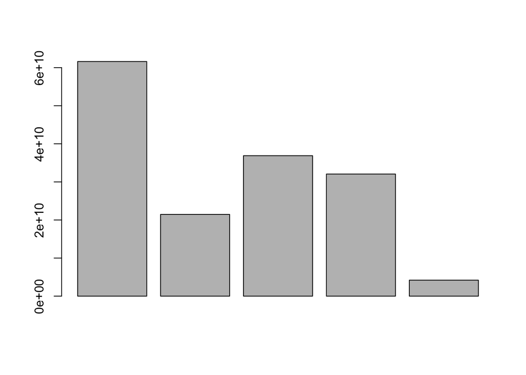

```r
# plot importance
barplot(importance$Overall)
```

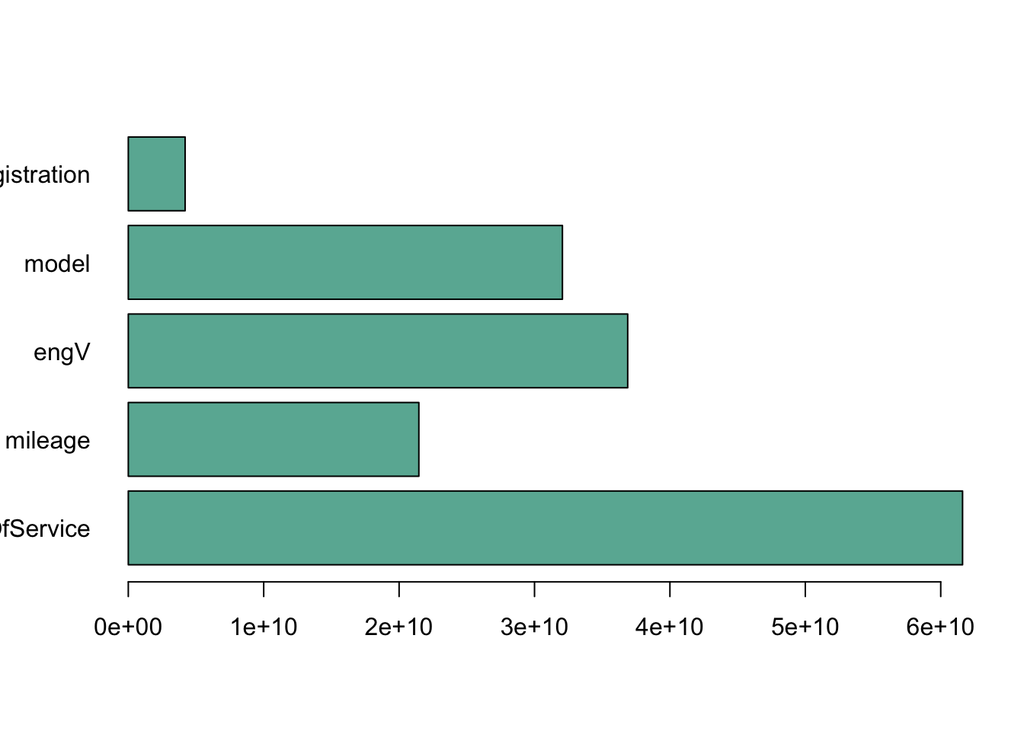

```r
barplot(height=importance$Overall, names=rownames(importance),
        col="#69b3a2", horiz=T , las=1)
```

## Model - K Cross Validation method

Since Random Forest model has been performing the best, it will be used to in this experiment. 3 folds will created, one will set out as the hold-out set and the other two will be used to train the model. This is because the computation ability of the computer is low and could not process the whole dataset repeatedly. The best one with the best score will be chosen.

```r
#specify the cross-validation method
cv_method <- trainControl(method = "cv", number = 3)

#fit a random forest regression model and use k-fold CV to evaluate performance
model <- train(price ~ ., data = df, method = "rf", trControl = cv_method)

print(model)
```

```
## Random Forest
##
## 6880 samples
##    5 predictor
##
## No pre-processing
## Resampling: Cross-Validated (3 fold)
## Summary of sample sizes: 4585, 4587, 4588
## Resampling results across tuning parameters:
##
##   mtry  RMSE      Rsquared   MAE
##   2     2880.357  0.7215760  1832.728
##   3     2876.869  0.7211822  1794.393
##   5     2888.755  0.7187998  1770.492
##
## RMSE was used to select the optimal model using the smallest value.
## The final value used for the model was mtry = 3.
```

## Model - Parameter hypertuning method

```r
mtry <- 2
#ntree: Number of trees to grow.
ntree <- 1


control <- trainControl(method='repeatedcv',
                        number=2,
                        repeats=1,
                        search = 'random')

#Random generate 15 mtry values with tuneLength = 15
set.seed(1)
rf_random <- train(price ~ .,
                   data = df,
                   method = 'rf',
                   metric = 'rsq',
                   tuneLength  = 5,
                   trControl = control)
print(rf_random)
```

```
## Random Forest
##
## 6880 samples
##    5 predictor
##
## No pre-processing
## Resampling: Cross-Validated (2 fold, repeated 1 times)
## Summary of sample sizes: 3440, 3440
## Resampling results across tuning parameters:
##
##   mtry  RMSE      Rsquared   MAE
##   1     3450.804  0.6532756  2466.447
##   2     2913.640  0.7136283  1882.728
##   3     2901.620  0.7152122  1847.127
##   5     2912.541  0.7134033  1826.355
##
## RMSE was used to select the optimal model using the smallest value.
## The final value used for the model was mtry = 3.
```

## Ensemble Methods

This model combines the probabilities and predictions from multiple machine learning models and selects the most common observation from all models based on average weightage of each model.

```r
# Get X_train and y_test values
X_train <- train_df %>% select(-price)
y_train <- train_df$price

# Fit the ensemble model
model <- SuperLearner(y_train,
                      X_train,
                      SL.library=list("SL.lm",
                                      "SL.ridge",
                                      "SL.nnls"))
# Return the model
model
```

```
##
## Call:
## SuperLearner(Y = y_train, X = X_train, SL.library = list("SL.lm", "SL.ridge",
##     "SL.nnls"))
##
##
##                   Risk      Coef
## SL.lm_All     16492217 0.0000000
## SL.ridge_All  16492177 0.1809342
## SL.nnls_All  104916237 0.8190658
```

The ensemble learner was trained on linear regression, ridge regression and non-negative least squares regression models. SVM and Random Forest regression models were not used since they took forever to run.

Lets use the model to predict test data and evaluate the model.

```r
rm(independent_test_data) #memory management
X_test <- test_df %>% select(-price)

# Predictions
predictions <- predict.SuperLearner(model, newdata=X_test)
y_predicted <- predictions$pred

# Evaluations
print(paste("R_squared score: ", r2.score(y_test, y_predicted)))
```

```
## [1] "R_squared score:  -1.56864299074858"
```

```r
print(paste("MAD score: ", mad(y_test, y_predicted)))
```

```
## [1] "MAD score:  9239.2751031009"
```

```r
print(paste("MSE score: ", mse(y_test, y_predicted)))
```

```
## [1] "MSE score:  74092609.0502966"
```

```r
print(paste("RMSE score: ", rmse(y_test, y_predicted)))
```

```
## [1] "RMSE score:  8607.70637570175"
```

The model performed poorly, poorer than single average line. It had a negative accuracy score. Single model surely performs better than the ensemble learner.